# STA 380 Homework 1

Henry Chang, Tiffany Sung, Joseph Chin

8/8/2018

# Problem 1 Probability Practice

## Part A

Given the following:  
Prob(RC) = 0.3  
Prob(Yes|RC) = Prob(No|RC) = 0.5  
Prob(TC) = 0.7  
Prob(Yes) = 0.65  
Prob(No) = 0.35

We want to know Prob(Yes|TC) = ?

Solution:  
Prob(Yes) = Prob(Yes|RC) $*$ Prob(RC) + Prob(Yes|TC) $*$ Prob(TC)  
0.65 = 0.5 $*$ 0.3 + Prob(Yes|TC) $*$ 0.7

```r
(0.65-0.3*0.5) / 0.7
## [1] 0.7142857
```

## Part B

The probability of having disease given test positive:  
D: having disease, ND: not having disease  
P: getting postivie in the test, N: getting negative in the test

P(D|P) = P(P|D) $*$ P(D) / ( P(P|D) $*$ P(D) + P(P|N) $*$ P(N) )

```r
(0.993) * 0.000025 / ((0.993) * 0.000025 + 0.0001 * 0.999975)
## [1] 0.1988824
```

Problem of the test lies in having too many “False Positive”. Which is giving too many positive on tests for those who don’t have a desease. This kind of implementing a universal testing policy for the disease will lead to panic and chaos.

# Problem 2 Green Buildings

```r
library(corrplot)
## corrplot 0.84 loaded
library(ggplot2)
plot_data = read.csv(url("https://raw.githubusercontent.com/jgscott/STA380/master/data/greenbuildings.csv"))
#colnames(plot_data)
re_order_var = c("Rent", "green_rating", "LEED","Energystar", "size", "stories", "class_a",
 "class_b", "amenities",  "age", "renovated", "cd_total_07", "hd_total07","total_dd_07", "Precipitation","Gas_Costs" , "Electricity_Costs", "net")
```

After reading our data into R. I reordered the variables by their categories to make correlation plots easier to read. Our new variable list starts with rent, green building certificate, characteristics of a building, weather indicators, ends with energy and other cost.

## Variable correlation plot

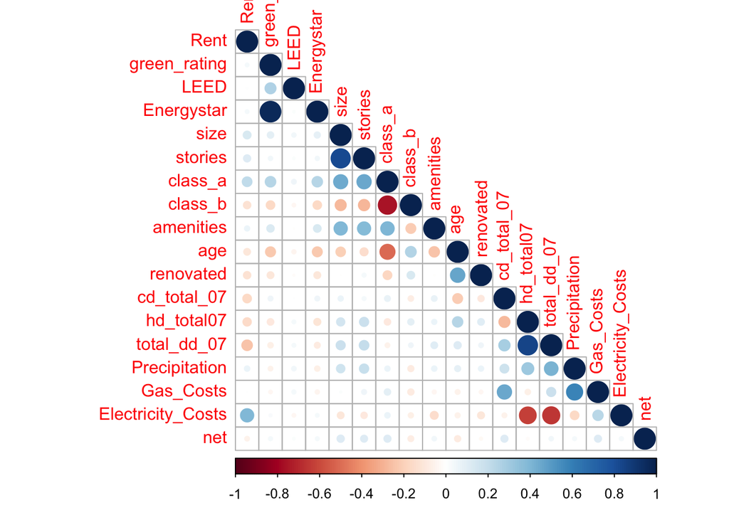

```r
corrplot(cor(plot_data[re_order_var]), type = "lower")
```

The correlations seems reasonable: rent postiviely correlated to good characteristics of a building and negatively correlated to worse building conditions and less favorable weather conditions.  
However, “cluster_rent” provides aggregated information by cluster. Which cannot be included in our correlation plot but provides valuable information.

Therefore, we created varaiable “Rent_adjust” by dividing rent using its cluster’s rent. Which tells us the house’s rent proportional to the cluster’s rent.

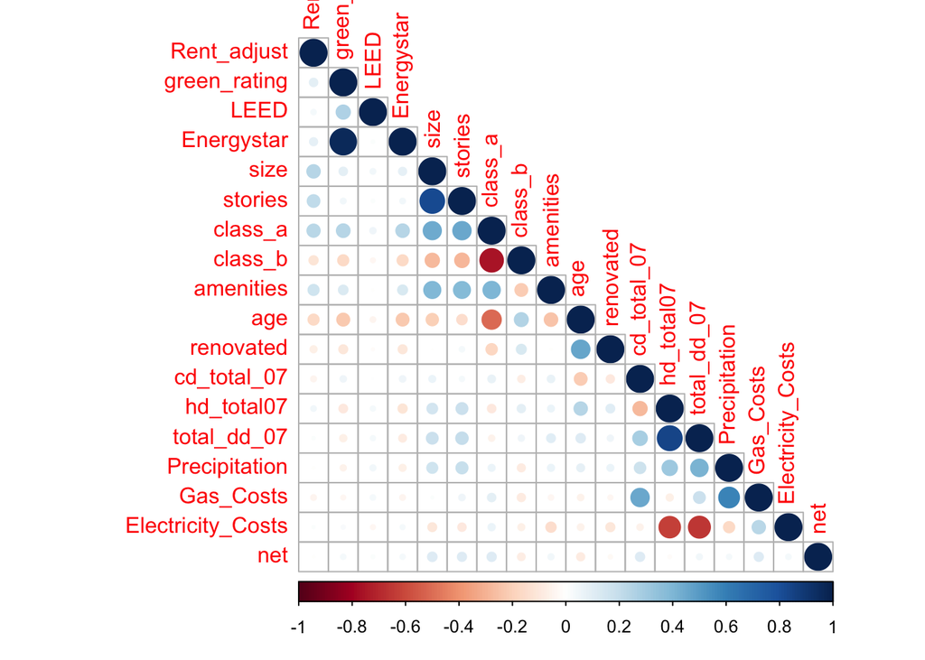

```r
plot_data["Rent_adjust"] = plot_data["Rent"] / plot_data["cluster_rent"]
corrplot(cor(plot_data[c("Rent_adjust", re_order_var[-1])]), type = "lower")
```

After replacing Rent using “Rent_adjust”, we found that correlations between “Rent_adjust” and weather related variables has dissappeared. Which seems to tell us that the effect of weather on rent are reflected on the cluster’s rent.

##### Examine rent difference between green and non-green buildings having similar characteristic with our new building.

After we have studied our variables, we look into information we have on our new building :  
size, age, and stories to help us decide whether we should build a green building.

#### Size

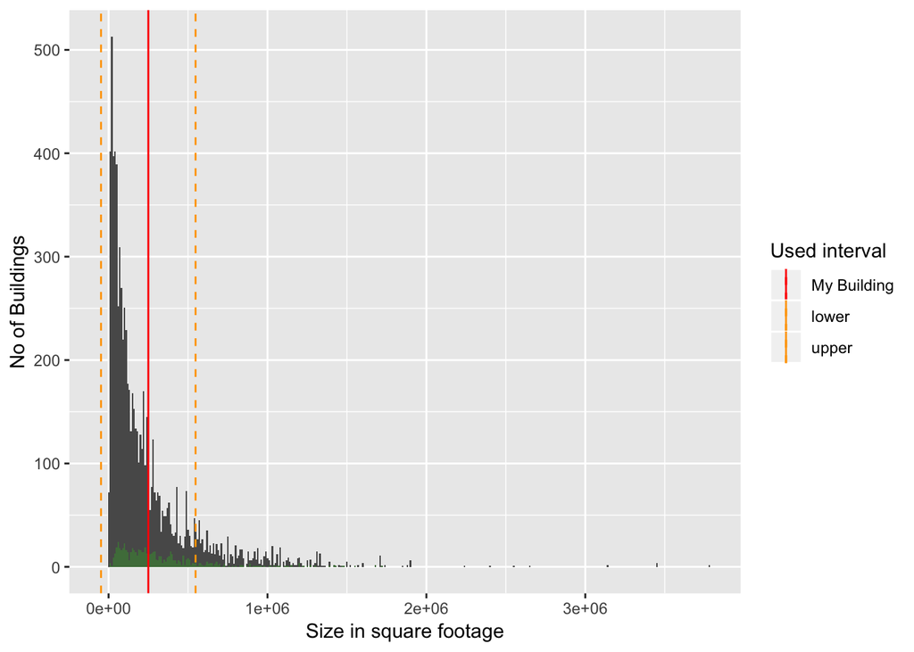

```r
size_sd = sd(plot_data$size)
ggplot(plot_data, aes(x = size)) +
  geom_histogram(binwidth = 10000) +
  geom_histogram(data=subset(plot_data, green_rating == "1"),binwidth = 10000,fill = "green", alpha = 0.2) +
  labs( x = "Size in square footage", y ="No of Buildings" ) +
  geom_vline(aes(xintercept = 250000, color = "My Building")) +
  geom_vline(aes(xintercept = 250000 + size_sd, color = "upper") , linetype = "dashed") +
  geom_vline(aes(xintercept = 250000 - size_sd, color = "lower"), linetype = "dashed") +
  scale_color_manual(name="Used interval", values=c(`My Building` = "red", upper = "orange", lower = "orange"))
```

We plot the “size” variable’s distribution of our entire data along with the green building’s size distribution colored in green. The vertical red line shows the our building’s size : 250000. And the orange dash line shows interval of one standard deviation, in which are the data points we are carrying to our boxplot.

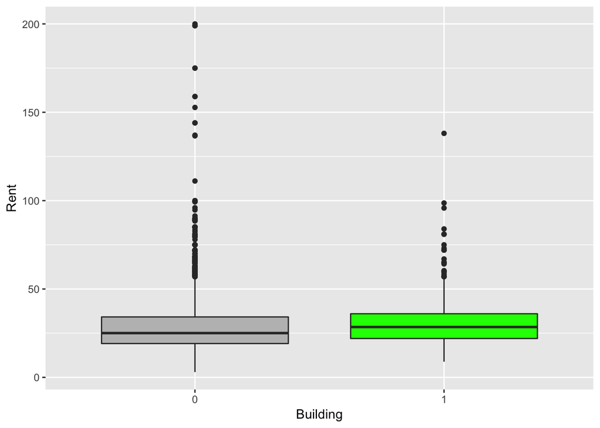

```r
size_explore = plot_data[plot_data$size <=  250000 + size_sd, ]
size_explore = size_explore[size_explore$size >= 250000 - size_sd, ]
size_explore$green_rating = as.factor(size_explore$green_rating)
ggplot(size_explore, aes(x = green_rating, y = Rent) ) +
  geom_boxplot(fill = c("grey", "green")) +
  #scale_y_continuous(limit = c(0, 50)) +
  labs(x = "Building", y = "Rent")
```

Using the data points having less than one standard deviation on “size” with our new building, we plotted the rent difference between green and non-green buildings.

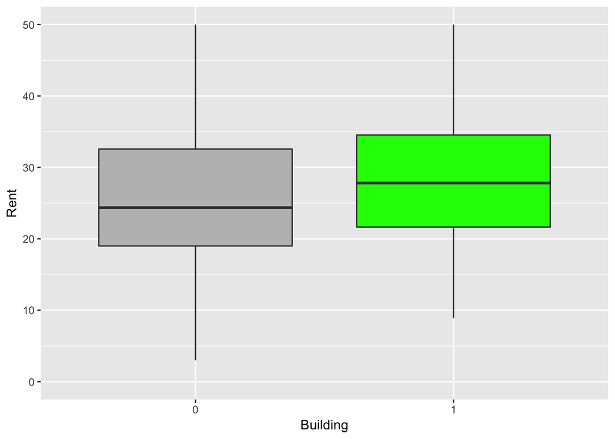

```r
size_explore = plot_data[plot_data$size <=  250000 + size_sd, ]
size_explore = size_explore[size_explore$size >= 250000 - size_sd, ]
size_explore$green_rating = as.factor(size_explore$green_rating)
ggplot(size_explore, aes(x = green_rating, y = Rent) ) +
  geom_boxplot(fill = c("grey", "green")) +
  scale_y_continuous(limit = c(0, 50)) +  # 363 among 6998 have rent > 50
  labs(x = "Building", y = "Rent")
```

We zoom in our plot by resetting Y limit. We found that 25, 50, 75 rent quantile of green buildings are all higher than non-green buildings.

#### Age

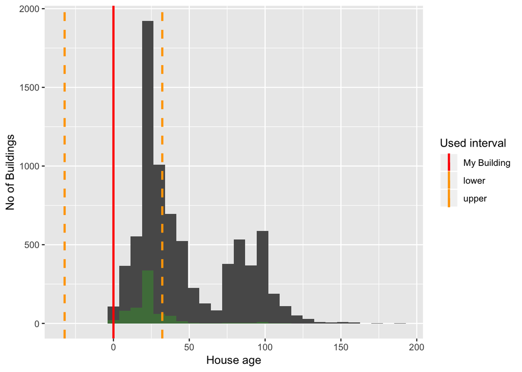

```r
age_sd = sd(plot_data$age)
ggplot(plot_data, aes(x = age)) +
  geom_histogram() +
  geom_histogram(data=subset(plot_data, green_rating == "1"),fill = "green", alpha = 0.2) +
  labs( x = "House age", y ="No of Buildings" ) +
  geom_vline(aes(xintercept = 0, color = "My Building"), size = 1) +
  geom_vline(aes(xintercept = 0 + age_sd, color = "upper") , linetype = "dashed", size = 1) +
  geom_vline(aes(xintercept = 0 - age_sd, color = "lower"), linetype = "dashed", size = 1) +
  scale_color_manual(name="Used interval", values=c(`My Building` = "red",
                                                    upper = "orange",
                                                    lower = "orange"))
```

We plot the “age” variable’s distribution along with “age”’s distribution among green buildings. We found new buildings (age = 0) only consist of a small portion of our data.

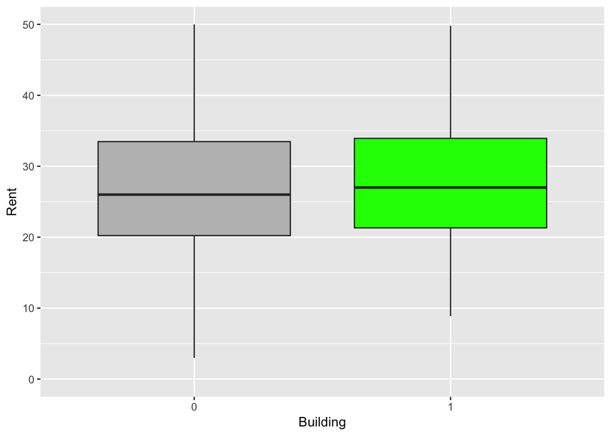

```r
age_explore = plot_data[plot_data$age <=  age_sd, ]
age_explore$green_rating = as.factor(age_explore$green_rating)
ggplot(age_explore, aes(x = green_rating, y = Rent)) +
      geom_boxplot(fill = c("grey", "green")) +
      scale_y_continuous(limit = c(0, 50)) + #173 among 3740 have rent > 50
      labs(x = "Building", y = "Rent")
```

Green buildings have higher rents in relatively new buildings.

#### Stories

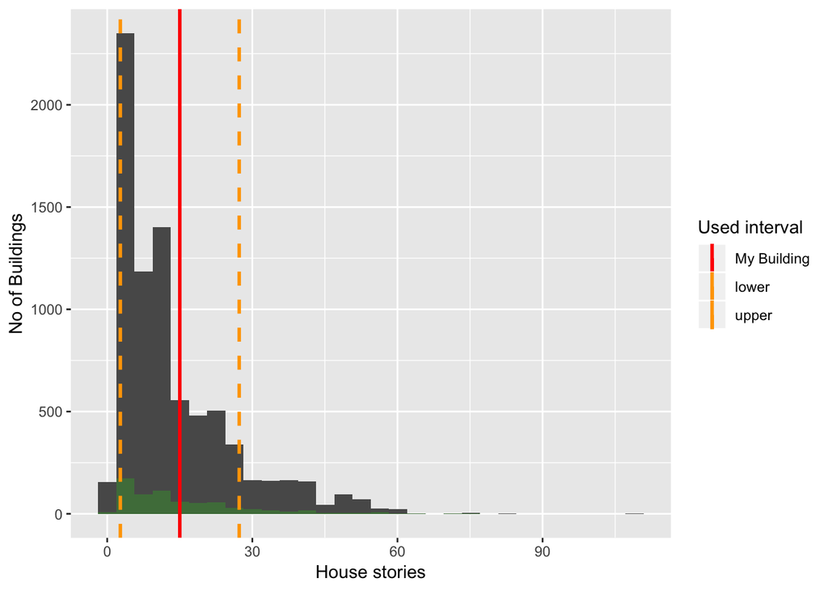

```r
stories_sd = sd(plot_data$stories)
ggplot(plot_data, aes(x = stories)) +
  geom_histogram() +
  geom_histogram(data=subset(plot_data, green_rating == "1"),fill = "green", alpha = 0.2) +
  labs( x = "House stories", y ="No of Buildings" ) +
  geom_vline(aes(xintercept = 15, color = "My Building"), size = 1) +
  geom_vline(aes(xintercept = 15 + stories_sd, color = "upper") , linetype = "dashed", size = 1) +
  geom_vline(aes(xintercept = 15 - stories_sd, color = "lower"), linetype = "dashed", size = 1) +
  scale_color_manual(name="Used interval", values=c(`My Building` = "red",
                                                    upper = "orange",
                                                    lower = "orange"))
```

Under the distribution of “stories”, we can see that our new buildings story is around 70 quantile among our data set.

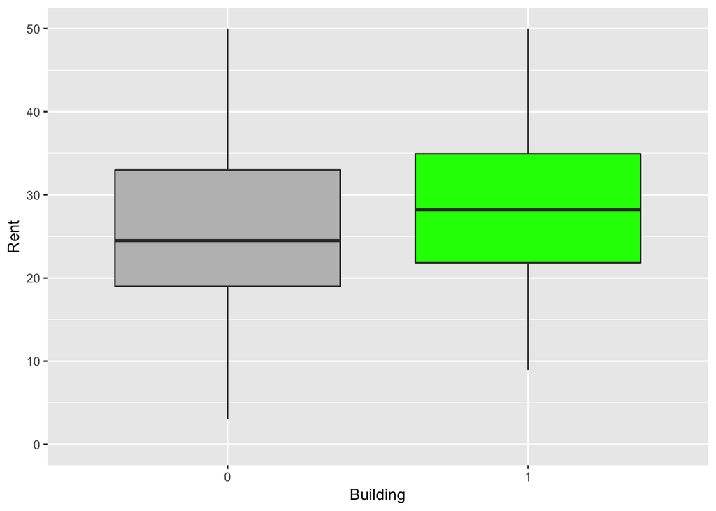

```r
stories_explore = plot_data[plot_data$stories <= 15 + stories_sd, ]
stories_explore = stories_explore[stories_explore$stories >= 15 - stories_sd, ]
stories_explore$green_rating = as.factor(stories_explore$green_rating)
ggplot(stories_explore, aes(x = green_rating, y = Rent)) +
  geom_boxplot(fill = c("grey", "green")) +
  scale_y_continuous(limit = c(0, 50)) +  #173 among 3740 have rent > 50
  labs(x = "Building", y = "Rent")
```

Green buildings can bring higher rent in our stories interval.

## Validation using regression

On plots above we obsereved higher rents from green buildings under different condition controled. Before coming up with our final advice, it’s always good to check the result of linear regression, which is good at controling variables we consider might affect our rent.

We used Rent_adjust as dependent variable to control the effect from clusters. Then added class_a to control the raised rent from high-quality buildings .

```r
summary(lm( Rent_adjust ~ log(size) + age + stories+ class_a +green_rating ,
            data = plot_data))
```

```
##
## Call:
## lm(formula = Rent_adjust ~ log(size) + age + stories + class_a +
##     green_rating, data = plot_data)
##
## Residuals:
##     Min      1Q  Median      3Q     Max
## -0.9002 -0.1413 -0.0251  0.0899  3.4442
##
## Coefficients:
##                Estimate Std. Error t value Pr(>|t|)
## (Intercept)   0.6550154  0.0454151  14.423  < 2e-16 ***
## log(size)     0.0307891  0.0042013   7.328 2.56e-13 ***
## age          -0.0005894  0.0001151  -5.121 3.11e-07 ***
## stories       0.0014500  0.0004035   3.594 0.000328 ***
## class_a       0.0528742  0.0088073   6.003 2.02e-09 ***
## green_rating  0.0333510  0.0117117   2.848 0.004416 **
## ---
## Signif. codes:  0 '***' 0.001 '**' 0.01 '*' 0.05 '.' 0.1 ' ' 1
##
## Residual standard error: 0.2797 on 7888 degrees of freedom
## Multiple R-squared:  0.08143,    Adjusted R-squared:  0.08085
## F-statistic: 139.9 on 5 and 7888 DF,  p-value: < 2.2e-16
```

Green building provides 3.3% increase on local cluster rent per square foot. (Our building 250,000 square foot, extra cost for green: 5,000,000)

# Problem 3 Bootstrapping

```r
library(mosaic)
library(quantmod)
library(foreach)
```

```r
# Import the five ETFs
mystocks = c("SPY", "TLT", "LQD", "EEM", "VNQ")
myprices = getSymbols(mystocks, from = "2007-01-01")
```

[output not shown]

[output not shown]

```r
getSymbols(mystocks)
```

```
## [1] "SPY" "TLT" "LQD" "EEM" "VNQ"
```

```r
#Get the adjusted closing price of each ETF
for(ticker in mystocks) {

  expr = paste0(ticker, "a = adjustOHLC(", ticker, ")")
  eval(parse(text=expr))
}

# Combine all the returns in a matrix
all_returns = cbind(ClCl(LQDa),ClCl(TLTa),ClCl(SPYa), ClCl(VNQa), ClCl(EEMa))
all_returns = as.matrix(na.omit(all_returns))

head(all_returns)
```

```
##                ClCl.LQDa    ClCl.TLTa     ClCl.SPYa    ClCl.VNQa
## 2007-01-04  0.0075152938  0.006063328  0.0021221123  0.001296655
## 2007-01-05 -0.0006526807 -0.004352668 -0.0079763183 -0.018518518
## 2007-01-08 -0.0002798843  0.001793566  0.0046250821  0.001451392
## 2007-01-09  0.0001866169  0.000000000 -0.0008498831  0.012648208
## 2007-01-10 -0.0013063264 -0.004475797  0.0033315799  0.012880523
## 2007-01-11 -0.0030832664 -0.005844712  0.0043804651  0.012973706
##               ClCl.EEMa
## 2007-01-04 -0.013809353
## 2007-01-05 -0.029238205
## 2007-01-08  0.007257535
## 2007-01-09 -0.022336235
## 2007-01-10 -0.002303160
## 2007-01-11  0.012650112
```

```r
# The sample correlation matrix
cor(all_returns)
```

```
##            ClCl.LQDa  ClCl.TLTa  ClCl.SPYa   ClCl.VNQa   ClCl.EEMa
## ClCl.LQDa 1.00000000  0.4322842  0.1013804  0.07150394  0.08796019
## ClCl.TLTa 0.43228418  1.0000000 -0.4361864 -0.25339288 -0.16741492
## ClCl.SPYa 0.10138038 -0.4361864  1.0000000  0.76825388  0.40655931
## ClCl.VNQa 0.07150394 -0.2533929  0.7682539  1.00000000  0.29231279
## ClCl.EEMa 0.08796019 -0.1674149  0.4065593  0.29231279  1.00000000
```

From the correlation plot, we can see that SPY is highly correlated with VNQ and EEM which indicates that emerging-market and real estate relatively more dominant by the market condition. Also, we noticed that TLT is negatively correlated with SPY. This can be explained as when the stock market goes up, people tend to sell treasury bonds to buy stocks, and when it goes down, people buy treasury bonds because they are safe.

```r
library(GGally)
```

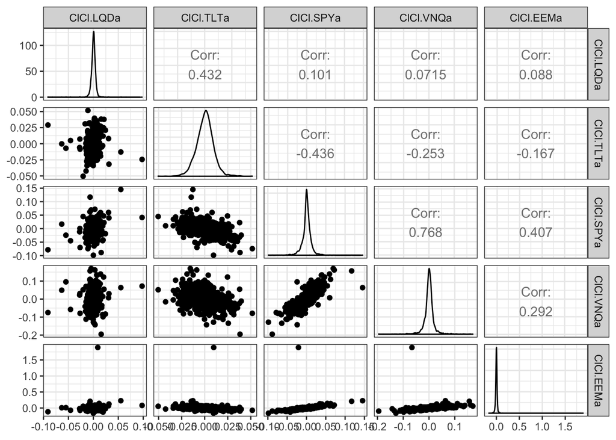

```r
ggpairs(as.data.frame(all_returns))+theme_bw()
```

From the mean and variance of each ETFs, we can see that EEM, VNQ have relatively higher return, but higher risk consequently. Thus, we can then assume EEM and VNQ is a risker investment compare to the other ETFs. This is also very intuitive because investing in bonds is less risky than investing in emerging-market or real estate which are both highly volatile.

```r
#The mean and variance
sort(apply(all_returns,2,mean),decreasing = TRUE)
```

```
##    ClCl.EEMa    ClCl.VNQa    ClCl.SPYa    ClCl.TLTa    ClCl.LQDa
## 0.0009971055 0.0004095163 0.0003983176 0.0002737537 0.0002067942
```

```r
cat("\n")
```

```r
sort(apply(all_returns,2,var),decreasing = TRUE)
```

```
##    ClCl.EEMa    ClCl.VNQa    ClCl.SPYa    ClCl.TLTa    ClCl.LQDa
## 1.619315e-03 4.477357e-04 1.549636e-04 8.384931e-05 2.724362e-05
```

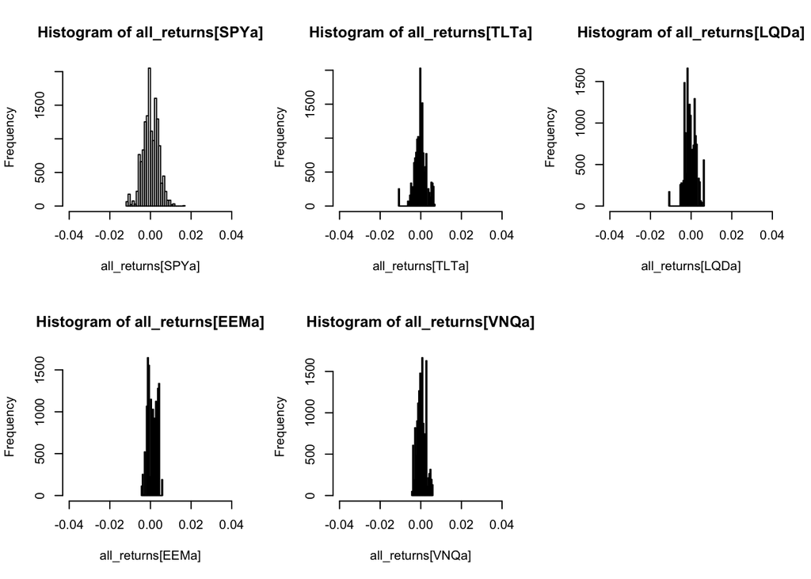

```r
par(mfrow=c(2,3))
hist(all_returns[SPYa], 30, xlim=c(-0.04, 0.04))
hist(all_returns[TLTa], 30, xlim=c(-0.04, 0.04))
hist(all_returns[LQDa], 30, xlim=c(-0.04, 0.04))
hist(all_returns[EEMa], 30, xlim=c(-0.04, 0.04))
hist(all_returns[VNQa], 30, xlim=c(-0.04, 0.04))
```

**Evenly Weighted Portfolio** First, we construct a portfolio which the initial wealth is evenly distributed into each ETFs.

```r
initial_wealth = 100000
sim_even_split = foreach(i=1:5000, .combine='rbind') %do% {
  total_wealth = initial_wealth
  weights = c(0.2, 0.2, 0.2, 0.2, 0.2) #seperate evenly
  holdings = weights * total_wealth
  n_days = 20
  wealthtracker = rep(0, n_days)
  for(today in 1:n_days) {
    return.today = resample(all_returns, 1, orig.ids=FALSE)
    holdings = holdings + holdings*return.today #p+r(stock)
    total_wealth = sum(holdings)#p+r(portfolio)
    wealthtracker[today] = total_wealth
    holdings = total_wealth * weights #daily rebalance
  }
  wealthtracker
}
```

```r
even_mean <- mean(sim_even_split[,n_days])
even_return <- (mean(sim_even_split[,n_days])-initial_wealth)/initial_wealth
even_5_perc <- quantile(sim_even_split[,n_days], 0.05) - initial_wealth

# Print out results
cat("For an even split investment of $100,000,\nExpected holdings:", even_mean, "\nReturn Rate:", even_return, "\n5% VaR:", even_5_perc)
```

```
## For an even split investment of $100,000,
## Expected holdings: 100814.9
## Return Rate: 0.008148823
## 5% VaR: -6582.916
```

**Safer Portfolio** Then, according to the mean and variance analysis of each ETFs, we want to construct a more risk-adverse portfolio by weighted toward the less-volatile ETFs for instance, SPY,TLT and LQD. We decided not to put any weight on EEM and VNQ because accoding to the correlation plot, these two ETF has relatively higher correlation with SPY which is the market index. If we put them in the portfolio, it would not diverse and reduce the risk.

```r
# Now simulate many different possible scenarios when investing
# over a 4-week (20 trading day) period
initial_wealth = 100000
sim_safe_split = foreach(i=1:5000, .combine='rbind') %do% {
  total_wealth = initial_wealth
  weights = c(0.5, 0.3, 0.2, 0, 0) # 0.2 SPY, 0.3 TLT, 0.5 LQD
  holdings = weights * total_wealth
  n_days = 20
  wealthtracker = rep(0, n_days)
  for(today in 1:n_days) {
    return.today = resample(all_returns, 1, orig.ids=FALSE)
    holdings = holdings + holdings*return.today
    total_wealth = sum(holdings)
    wealthtracker[today] = total_wealth
    holdings = total_wealth * weights
  }
  wealthtracker
}
#safe_hist = hist(sim_safe_split[,n_days]- initial_wealth, breaks=30)
```

```r
safe_mean <- mean(sim_safe_split[,n_days])
safe_return <- (mean(sim_safe_split[,n_days])-initial_wealth)/initial_wealth
safe_5_perc <- quantile(sim_safe_split[,n_days], 0.05) - initial_wealth

# Print out results
cat("For an safer split investment of $100,000,\nExpected holdings:",safe_mean, "\nReturn Rate:", safe_return, "\n5% VaR:", safe_5_perc)
```

```
## For an safer split investment of $100,000,
## Expected holdings: 100469.8
## Return Rate: 0.004698196
## 5% VaR: -2924.658
```

**Aggressive Portfolio** For the aggressive portfolio, we merely place our initial wealth on the risker investment EEM and VNQ. We did not place any holdings on the other ETFs because if we added them in the portfolio, it would diversify the risk and make the portfolio less aggressive.

```r
initial_wealth = 100000
sim_risky_split = foreach(i=1:5000, .combine='rbind') %do% {
  total_wealth = initial_wealth
  weights = c(0, 0, 0, 0.3, 0.7) #0.7 EEM, 0.3 VNQ
  holdings = weights * total_wealth
  n_days = 20
  wealthtracker = rep(0, n_days)
  for(today in 1:n_days) {
    return.today = resample(all_returns, 1, orig.ids=FALSE)
    holdings = holdings + holdings*return.today
    total_wealth = sum(holdings)
    wealthtracker[today] = total_wealth
    holdings = total_wealth * weights
  }
  wealthtracker
}
#risk_hist = hist(sim_risky_split[,n_days]- initial_wealth, breaks=30)
```

```r
risky_mean <- mean(sim_risky_split[,n_days])
risky_return <- (mean(sim_risky_split[,n_days])-initial_wealth)/initial_wealth
risky_5_perc <- quantile(sim_risky_split[,n_days], 0.05) - initial_wealth

# Print out results
cat("For a risky split investment of $100,000,\nExpected holdings:", risky_mean, "\nReturn Rate:", risky_return, "\n5% VaR:", risky_5_perc)
```

```
## For a risky split investment of $100,000,
## Expected holdings: 101830.8
## Return Rate: 0.01830756
## 5% VaR: -12645.26
```

With the histogram below, again, we prove that portfolio that place higher proportions on ETFs with higher variance could be more volatile. The ‘risk’ portfolio has more chances of getting higher returns and also more loss. The ‘safe’ is the lower-volatility portfolio and as expected, it has lower chances of getting big profit or big loss.

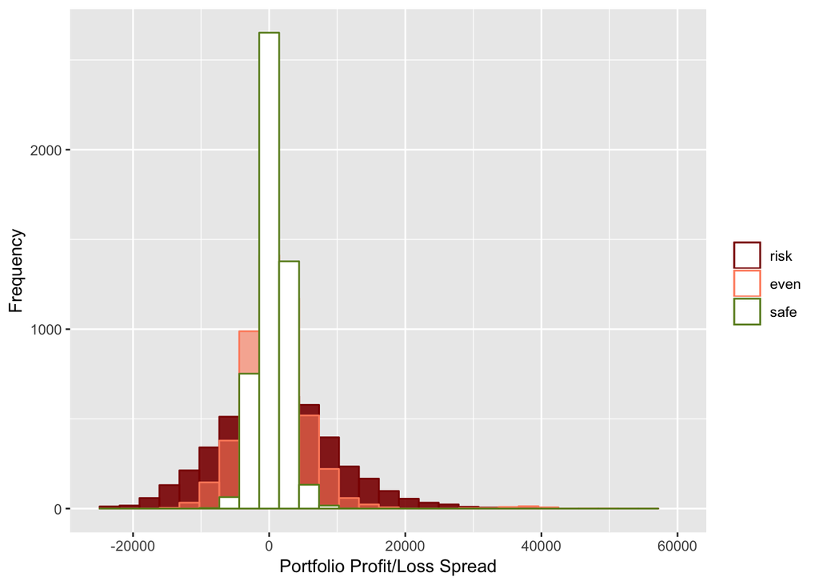

```r
even = sim_even_split[,n_days]- initial_wealth
safe = sim_safe_split[,n_days]- initial_wealth
risk = sim_risky_split[,n_days]- initial_wealth

plot_df = data.frame(risk,even, safe)

ggplot(data = plot_df) +
    geom_histogram(aes(risk,color = 'risk'), fill="red4",alpha = 0.9,position="identity")+
    geom_histogram(aes(even,color = 'even'),fill = 'salmon1',alpha = 0.6,position="identity") +
    geom_histogram(aes(safe,color = 'safe'),fill = 'white',alpha = 1.0,position="identity")+
    xlim(c(-25000,60000))+
    xlab('Portfolio Profit/Loss Spread')+
    ylab('Frequency')+
    scale_colour_manual("",
                      breaks = c("risk", "even", "safe"),
                      values = c("salmon1", "red4","olivedrab4"))
```

**Evaluate Portfolio Performance**

```r
get_return = function(initial_wealth,weights,all_returns){

    sim_split = foreach(i = 1:5000, .combine = 'rbind') %do% {
        total_wealth = initial_wealth
        holdings = weights * total_wealth
        n_days = 20
        wealthtracker = rep(0, n_days)
        for(today in 1:n_days) {
            return.today = resample(all_returns, 1, orig.ids=FALSE)
            holdings = holdings + holdings*return.today #p+r(stock)
            total_wealth = sum(holdings)#p+r(portfolio)
            wealthtracker[today] = total_wealth
            holdings = total_wealth * weights #daily rebalance
        }
        wealthtracker
    }
    return(quantile(sim_split[,n_days], 0.05) - initial_wealth)
}

#weight_even = rep(0.2,5)
#even = get_return(100000,weight_uni,all_returns)
```

Once again, by randomly tuning the weight on those 5 ETFs, we can observe that if placing more holdings on the higher-volatility ETFs, we would expect it to lose more money of the portfolios during the worst 5% of possible 20-day periods.

```r
set.seed(1)
weight = runif(5)
weight = weight / sum(weight)
for (i in 1:10){
    weight = runif(5)
    weight = weight / sum(weight)
    initial_wealth = 100000
    VaR = get_return(initial_wealth,weight,all_returns)
    cat('The portfolio weight is: ')
    print(weight)
    cat('VaR of the portfolio is: ')
    print(VaR)
}
```

```
## The portfolio weight is: [1] 0.28120698 0.29569494 0.20683781 0.19692041 0.01933986
## VaR of the portfolio is:        5%
## -4440.452
## The portfolio weight is: [1] 0.06473905 0.45353950 0.19643722 0.00748451 0.27779972
## VaR of the portfolio is:        5%
## -4764.893
## The portfolio weight is: [1] 0.2317894 0.1058172 0.1834601 0.2476991 0.2312342
## VaR of the portfolio is:        5%
## -7119.731
## The portfolio weight is: [1] 0.37746475 0.15186376 0.19061732 0.18721150 0.09284268
## VaR of the portfolio is:       5%
## -4935.68
## The portfolio weight is: [1] 0.001673649 0.352725081 0.217737384 0.140157414 0.287706472
## VaR of the portfolio is:        5%
## -6368.566
## The portfolio weight is: [1] 0.0005496292 0.2491131647 0.3524609624 0.3284036533 0.0694725904
## VaR of the portfolio is:        5%
## -7499.073
## The portfolio weight is: [1] 0.18054499 0.08488587 0.24893533 0.28819775 0.19743606
## VaR of the portfolio is:        5%
## -7961.387
## The portfolio weight is: [1] 0.2102807 0.1492866 0.1785018 0.2136476 0.2482834
## VaR of the portfolio is:        5%
## -6775.995
## The portfolio weight is: [1] 0.19093565 0.39039666 0.06379952 0.03689110 0.31797707
## VaR of the portfolio is:        5%
## -4547.755
## The portfolio weight is: [1] 0.22974677 0.40298065 0.07596301 0.11979554 0.17151403
## VaR of the portfolio is:        5%
## -4306.324
```